# Introduction to the R package statVisual

## 8.3 Heatmap with Row Names Colored by Groups

Heatmap can be used to visualize the patterns among data. Usually results of bi-clustering will be superimposed to the heatmap. To check if the bi-clustering results match the known group information, we can color the nodes (i.e., rownames of the heatmap) by groups. The function *Heat* can do this task:

```r
data(esSim)
dat = exprs(esSim)
print(dim(dat))
```

```
#> [1] 100  20
```

```r
print(dat[1:2,])
```

```
#>           subj1    subj2    subj3    subj4    subj5    subj6    subj7    subj8
#> probe1 1.462929 1.596203 2.252267 1.974616 1.842606 1.677204 2.242665 1.705923
#> probe2 1.574342 2.232537 1.846260 1.980999 2.483777 2.048599 1.786081 1.934728
#>           subj9   subj10     subj11     subj12      subj13    subj14     subj15
#> probe1 1.758028 1.919597 0.07477602  0.3054811  0.12356526 0.3221119 -0.1346480
#> probe2 1.740329 1.942189 0.08308643 -0.1012774 -0.06669481 0.5413783  0.0245575
#>             subj16     subj17    subj18     subj19     subj20
#> probe1 -0.03845011  0.3504460 0.4173905 -0.1438801  0.3335083
#> probe2 -0.03849619 -0.2536194 0.1420066 -0.1072697 -0.1750033
```

```r
# phenotype data
pDat = pData(esSim)
print(dim(pDat))
```

```
#> [1] 20  2
```

```r
print(pDat[1:2,])
```

```
#>         sid grp
#> subj1 subj1   1
#> subj2 subj2   1
```

```r
# choose the first 6 probes (3 OE probes, 2 UE probes, and 1 NE probe)
pDat$probe1 = dat[1,]
pDat$probe2 = dat[2,]
pDat$probe3 = dat[3,]
pDat$probe4 = dat[4,]
pDat$probe5 = dat[5,]
pDat$probe6 = dat[6,]

print(pDat[1:2, ])
```

```
#>         sid grp   probe1   probe2   probe3    probe4    probe5    probe6
#> subj1 subj1   1 1.462929 1.574342 2.015327 -2.137848 -1.992898 1.0472686
#> subj2 subj2   1 1.596203 2.232537 2.141727 -2.639981 -1.926786 0.3904537
```

```r
pDat$grp=factor(pDat$grp)
```

```r
Heat(
     data = pDat[, c(2:8)],
     group = 'grp')
```

We also can use the wrapper function *statVisual*:

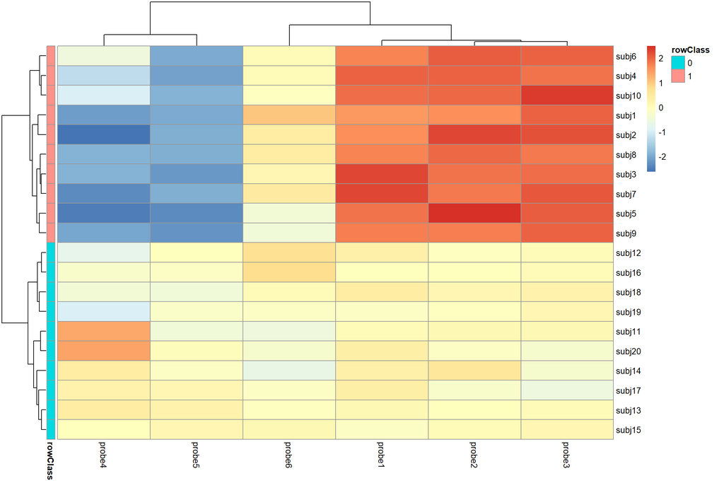

```r
statVisual(type = 'Heat',
           data = pDat[, c(2:8)],
           group = 'grp')
```

## 8.4 PVCA plot

Principal variance component analysis (PVCA) is proposed to estimate the variability of experimental effects including batch by hybridizing two popular data analysis methods: principal component analysis (PCA) and variance components analysis (VCA). It can be used as a screening tool to determine which sources of variability (biological, technical or other) are most prominent in a given microarray dataset (https://www.niehs.nih.gov/research/resources/software/biostatistics/pvca/index.cfm).

The function *PVCA* draws the plot of the weighted average proportion variance versus effects:

```r
library(pvca)

# create a fake Batch variable
data(esSim)
esSim$Batch=c(rep("A", 4), rep("B", 6), rep("C", 10))
```

```r
PVCA(
     clin_data = pData(esSim),
     clin_subjid = "sid",
     gene_data = exprs(esSim),
     batch.factors = c("grp", "Batch"))
```

We can also use the wrapper function *statVisual*:

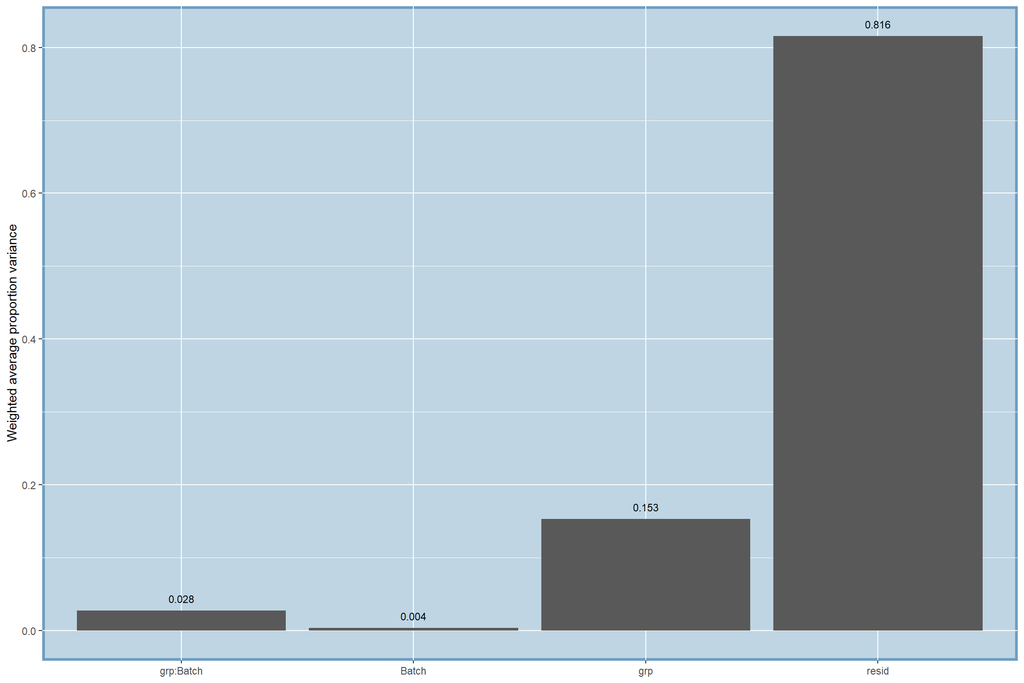

```r
statVisual(type = 'PVCA',
           clin_data = pData(esSim),
           clin_subjid = "sid",
           gene_data = exprs(esSim),
           batch.factors = c("grp", "Batch"))
```

## 8.5 Volcano Plot

Volcano plot can be used to check if the significant results are reasonable or not. Intuitively, the significant results (with low p-value) should have large absolute values of regression coefficients (in linear regression) or $log2$(odds ratios) (in logistic regression). To draw the plot of the relationship between fold change (odds ratio) vs. $-log10$(p value) with the option to label significant results, we can use the function *Volcano*:

```r
library(ggrepel)
library(limma)

library(ggrepel)
library(limma)

# load the simulated dataset
data(esSim)
print(esSim)
```

```
#> ExpressionSet (storageMode: lockedEnvironment)
#> assayData: 100 features, 20 samples
#>   element names: exprs
#> protocolData: none
#> phenoData
#>   sampleNames: subj1 subj2 ... subj20 (20 total)
#>   varLabels: sid grp
#>   varMetadata: labelDescription
#> featureData
#>   featureNames: probe1 probe2 ... probe100 (100 total)
#>   fvarLabels: probeid gene chr
#>   fvarMetadata: labelDescription
#> experimentData: use 'experimentData(object)'
#> Annotation:
```

```r
# expression levels
y = exprs(esSim)
print(dim(y))
```

```
#> [1] 100  20
```

```r
print(y[1:2,])
```

```
#>           subj1    subj2    subj3    subj4    subj5    subj6    subj7    subj8
#> probe1 1.462929 1.596203 2.252267 1.974616 1.842606 1.677204 2.242665 1.705923
#> probe2 1.574342 2.232537 1.846260 1.980999 2.483777 2.048599 1.786081 1.934728
#>           subj9   subj10     subj11     subj12      subj13    subj14     subj15
#> probe1 1.758028 1.919597 0.07477602  0.3054811  0.12356526 0.3221119 -0.1346480
#> probe2 1.740329 1.942189 0.08308643 -0.1012774 -0.06669481 0.5413783  0.0245575
#>             subj16     subj17    subj18     subj19     subj20
#> probe1 -0.03845011  0.3504460 0.4173905 -0.1438801  0.3335083
#> probe2 -0.03849619 -0.2536194 0.1420066 -0.1072697 -0.1750033
```

```r
# phenotype data
pDat = pData(esSim)
print(dim(pDat))
```

```
#> [1] 20  2
```

```r
print(pDat)
```

```
#>           sid grp
#> subj1   subj1   1
#> subj2   subj2   1
#> subj3   subj3   1
#> subj4   subj4   1
#> subj5   subj5   1
#> subj6   subj6   1
#> subj7   subj7   1
#> subj8   subj8   1
#> subj9   subj9   1
#> subj10 subj10   1
#> subj11 subj11   0
#> subj12 subj12   0
#> subj13 subj13   0
#> subj14 subj14   0
#> subj15 subj15   0
#> subj16 subj16   0
#> subj17 subj17   0
#> subj18 subj18   0
#> subj19 subj19   0
#> subj20 subj20   0
```

```r
# design matrix
design = model.matrix(~grp, data = pDat)
print(design)
```

```
#>        (Intercept) grp
#> subj1            1   1
#> subj2            1   1
#> subj3            1   1
#> subj4            1   1
#> subj5            1   1
#> subj6            1   1
#> subj7            1   1
#> subj8            1   1
#> subj9            1   1
#> subj10           1   1
#> subj11           1   0
#> subj12           1   0
#> subj13           1   0
#> subj14           1   0
#> subj15           1   0
#> subj16           1   0
#> subj17           1   0
#> subj18           1   0
#> subj19           1   0
#> subj20           1   0
#> attr(,"assign")
#> [1] 0 1
```

```r
options(digits = 3)

# Ordinary fit
fit <- lmFit(y, design)
fit2 <- eBayes(fit)

# get result data frame
resFrame = topTable(fit2,coef = 2, number = nrow(esSim))
print(dim(resFrame))
```

```
#> [1] 100   6
```

```r
print(resFrame[1:2,])
```

```
#>        logFC AveExpr     t  P.Value adj.P.Val    B
#> probe5 -1.98  -1.082 -19.7 3.04e-15  1.66e-13 25.0
#> probe3  2.05   0.996  19.6 3.31e-15  1.66e-13 24.9
```

```r
resFrame$sigFlag  =  resFrame$adj.P.Val < 0.05

resFrame$probe  =  rownames(resFrame)
# make sure set NA to genes non-differentially expressed
resFrame$probe[which(resFrame$sigFlag == FALSE)] = NA

print(resFrame[1:2,])
```

```
#>        logFC AveExpr     t  P.Value adj.P.Val    B sigFlag  probe
#> probe5 -1.98  -1.082 -19.7 3.04e-15  1.66e-13 25.0    TRUE probe5
#> probe3  2.05   0.996  19.6 3.31e-15  1.66e-13 24.9    TRUE probe3
```

```r
print(table(resFrame$sigFlag, useNA = "ifany"))
```

```
#>
#> FALSE  TRUE
#>    95     5
```

```r
Volcano(
  resFrame = resFrame,
  stats = 'logFC',
  p.value = 'P.Value',
  group = 'sigFlag',
  rowname.var = 'probe',
  point.size = 1)
```

We also can use the wrapper function *statVisual*:

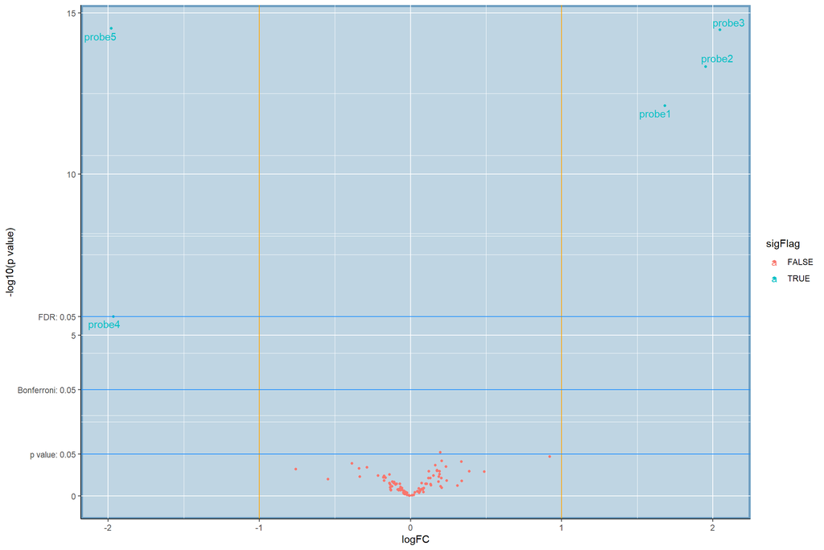

```r
statVisual(type = 'Volcano',
           resFrame = resFrame,
           stats = 'logFC',
           p.value = 'P.Value',
           group = 'sigFlag',
           rowname.var = 'probe',
           point.size = 1)
```

# 9 Analysis focusing on prediction:

## 9.1 Compare Box Plots with ROC Curve

To compare two distributions, we also can use parallel boxplots. Usually, the ultimate purpose of comparing two distribution is to evaluate if the variable can be used to predict the groups with high accuracy. Hence, we develop the function *BoxROC* to put parallel boxplots and ROC curve in the same figure. The area under ROC curve is also shown in the figure.

```r
library(dplyr)
library(gridExtra)

data(esSim)
print(esSim)
```

```
#> ExpressionSet (storageMode: lockedEnvironment)
#> assayData: 100 features, 20 samples
#>   element names: exprs
#> protocolData: none
#> phenoData
#>   sampleNames: subj1 subj2 ... subj20 (20 total)
#>   varLabels: sid grp
#>   varMetadata: labelDescription
#> featureData
#>   featureNames: probe1 probe2 ... probe100 (100 total)
#>   fvarLabels: probeid gene chr
#>   fvarMetadata: labelDescription
#> experimentData: use 'experimentData(object)'
#> Annotation:
```

```r
# expression data
dat = exprs(esSim)
print(dim(dat))
```

```
#> [1] 100  20
```

```r
print(dat[1:2,])
```

```
#>        subj1 subj2 subj3 subj4 subj5 subj6 subj7 subj8 subj9 subj10 subj11
#> probe1  1.46  1.60  2.25  1.97  1.84  1.68  2.24  1.71  1.76   1.92 0.0748
#> probe2  1.57  2.23  1.85  1.98  2.48  2.05  1.79  1.93  1.74   1.94 0.0831
#>        subj12  subj13 subj14  subj15  subj16 subj17 subj18 subj19 subj20
#> probe1  0.305  0.1236  0.322 -0.1346 -0.0385  0.350  0.417 -0.144  0.334
#> probe2 -0.101 -0.0667  0.541  0.0246 -0.0385 -0.254  0.142 -0.107 -0.175
```

```r
# phenotype data
pDat = pData(esSim)
print(dim(pDat))
```

```
#> [1] 20  2
```

```r
print(pDat[1:2,])
```

```
#>         sid grp
#> subj1 subj1   1
#> subj2 subj2   1
```

```r
pDat$grp = factor(pDat$grp)

# choose the first probe which is over-expressed in cases
pDat$probe1 = dat[1,]

# check histograms of probe 1 expression in cases and controls
print(table(pDat$grp, useNA = "ifany"))
```

```
#>
#>  0  1
#> 10 10
```

```r
BoxROC(
  data = pDat,
  group = 'grp',
  y = 'probe1',
  point.size = 1)
```

We also can use the wrapper function *statVisual*:

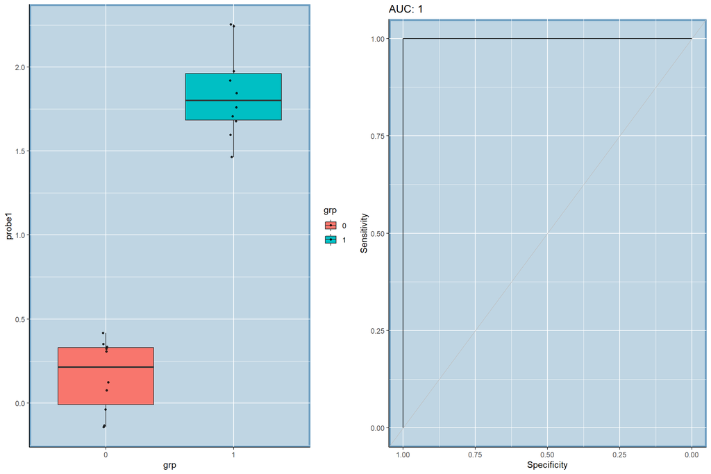

```r
statVisual(type = 'BoxROC',
           data = pDat,
           group = 'grp',
           y = 'probe1',
           point.size = 1)
```

## 9.2 Cross validation plot for glmnet

Cross validation plot can be used to visualize the estimated performance as a function of Lagrange multiplier. For continuous endpoint, mean square error (MSE) is used as performance metric. The function *cv_glmnet_plot* can do this task:

```r
library(dplyr)
library(tibble)
library(glmnet)


data(esSim)
print(esSim)
```

```
#> ExpressionSet (storageMode: lockedEnvironment)
#> assayData: 100 features, 20 samples
#>   element names: exprs
#> protocolData: none
#> phenoData
#>   sampleNames: subj1 subj2 ... subj20 (20 total)
#>   varLabels: sid grp
#>   varMetadata: labelDescription
#> featureData
#>   featureNames: probe1 probe2 ... probe100 (100 total)
#>   fvarLabels: probeid gene chr
#>   fvarMetadata: labelDescription
#> experimentData: use 'experimentData(object)'
#> Annotation:
```

```r
# expression data
dat = exprs(esSim)
print(dim(dat))
```

```
#> [1] 100  20
```

```r
print(dat[1:2,])
```

```
#>        subj1 subj2 subj3 subj4 subj5 subj6 subj7 subj8 subj9 subj10 subj11
#> probe1  1.46  1.60  2.25  1.97  1.84  1.68  2.24  1.71  1.76   1.92 0.0748
#> probe2  1.57  2.23  1.85  1.98  2.48  2.05  1.79  1.93  1.74   1.94 0.0831
#>        subj12  subj13 subj14  subj15  subj16 subj17 subj18 subj19 subj20
#> probe1  0.305  0.1236  0.322 -0.1346 -0.0385  0.350  0.417 -0.144  0.334
#> probe2 -0.101 -0.0667  0.541  0.0246 -0.0385 -0.254  0.142 -0.107 -0.175
```

```r
# phenotype data
pDat = pData(esSim)
print(dim(pDat))
```

```
#> [1] 20  2
```

```r
print(pDat[1:2,])
```

```
#>         sid grp
#> subj1 subj1   1
#> subj2 subj2   1
```

```r
# feature data
fDat = fData(esSim)
print(dim(fDat))
```

```
#> [1] 100   3
```

```r
print(fDat[1:2,])
```

```
#>        probeid      gene chr
#> probe1  probe1 fakeGene1   1
#> probe2  probe2 fakeGene2   1
```

```r
# choose the first 6 probes (3 OE probes, 2 UE probes, and 1 NE probe)
pDat$probe1 = dat[1,]
pDat$probe2 = dat[2,]
pDat$probe3 = dat[3,]
pDat$probe4 = dat[4,]
pDat$probe5 = dat[5,]
pDat$probe6 = dat[6,]

print(pDat[1:2, ])
```

```
#>         sid grp probe1 probe2 probe3 probe4 probe5 probe6
#> subj1 subj1   1   1.46   1.57   2.02  -2.14  -1.99   1.05
#> subj2 subj2   1   1.60   2.23   2.14  -2.64  -1.93   0.39
```

```r
# check histograms of probe 1 expression in cases and controls
print(table(pDat$grp, useNA = "ifany"))
```

```
#>
#>  0  1
#> 10 10
```

```r
pDat$grp = factor(pDat$grp)
```

```r
cv_glmnet_plot(x = as.matrix(pDat[, c(3:8)]),
               y = pDat$grp,
               family = "binomial")
```

We can also use the wrapper function *statVisual*:

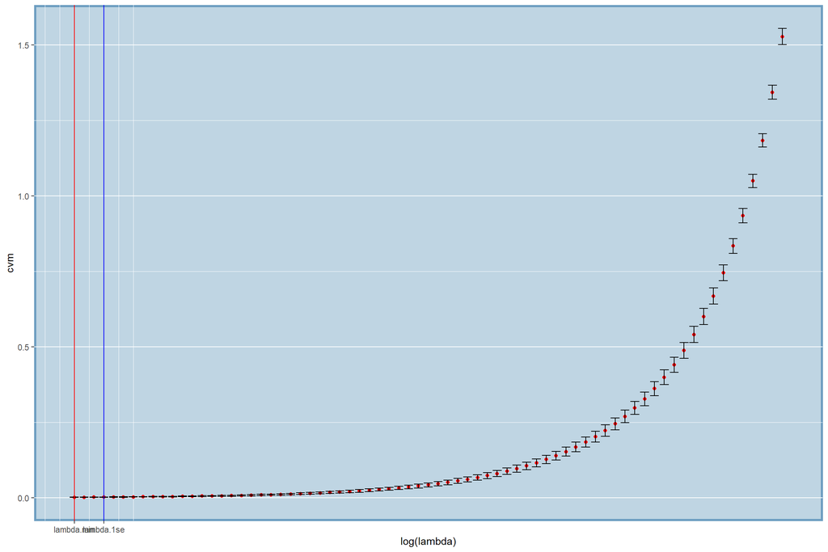

```r
statVisual(type = "cv_glmnet_plot",
           x = as.matrix(pDat[, c(3:8)]),
           y = pDat$grp,
           family = "binomial")
```

## 9.3 Variable Importance plot

The function *ImpPlot* can be used to visualize the relative importance of different variables in predicting outcome for random forest model.

```r
library(dplyr)
library(randomForest)
library(tibble)

data(esSim)
dat = exprs(esSim)
print(dim(dat))
```

```
#> [1] 100  20
```

```r
print(dat[1:2,])
```

```
#>        subj1 subj2 subj3 subj4 subj5 subj6 subj7 subj8 subj9 subj10 subj11
#> probe1  1.46  1.60  2.25  1.97  1.84  1.68  2.24  1.71  1.76   1.92 0.0748
#> probe2  1.57  2.23  1.85  1.98  2.48  2.05  1.79  1.93  1.74   1.94 0.0831
#>        subj12  subj13 subj14  subj15  subj16 subj17 subj18 subj19 subj20
#> probe1  0.305  0.1236  0.322 -0.1346 -0.0385  0.350  0.417 -0.144  0.334
#> probe2 -0.101 -0.0667  0.541  0.0246 -0.0385 -0.254  0.142 -0.107 -0.175
```

```r
# phenotype data
pDat = pData(esSim)
print(dim(pDat))
```

```
#> [1] 20  2
```

```r
print(pDat[1:2,])
```

```
#>         sid grp
#> subj1 subj1   1
#> subj2 subj2   1
```

```r
# choose the first 6 probes (3 OE probes, 2 UE probes, and 1 NE probe)
pDat$probe1 = dat[1,]
pDat$probe2 = dat[2,]
pDat$probe3 = dat[3,]
pDat$probe4 = dat[4,]
pDat$probe5 = dat[5,]
pDat$probe6 = dat[6,]

print(pDat[1:2, ])
```

```
#>         sid grp probe1 probe2 probe3 probe4 probe5 probe6
#> subj1 subj1   1   1.46   1.57   2.02  -2.14  -1.99   1.05
#> subj2 subj2   1   1.60   2.23   2.14  -2.64  -1.93   0.39
```

```r
pDat$grp=factor(pDat$grp)


rf_m = randomForest(
  x = pDat[, c(3:8)],
  y = pDat$grp,
  importance = TRUE, proximity = TRUE
)
```

```r
ImpPlot(rf_m)
```

We can also use the wrapper function *statVisual*:

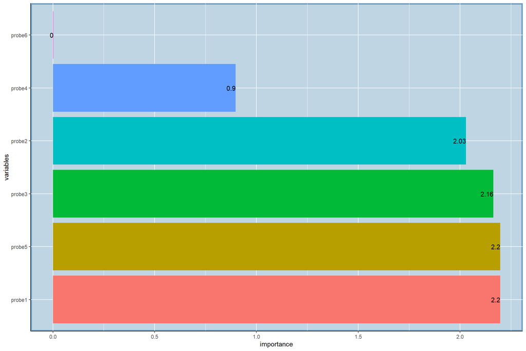

```r
statVisual(type = 'ImpPlot', rf_m)
```

# 10 Discussion

The R package *statVisual* that we developed extends existing R plot functions to help visualizing differences among groups for TM/BM applications.

We notice that R package *GGally* provides a powerful visualization function *ggpairs* that can put pairwise histograms, estimated densities, scatter plots, boxplots, correlation coefficients in one figure. For example,

```r
library(GGally)

data(esSim)
dat = exprs(esSim)
print(dim(dat))
```

```
#> [1] 100  20
```

```r
print(dat[1:2,])
```

```
#>        subj1 subj2 subj3 subj4 subj5 subj6 subj7 subj8 subj9 subj10 subj11
#> probe1  1.46  1.60  2.25  1.97  1.84  1.68  2.24  1.71  1.76   1.92 0.0748
#> probe2  1.57  2.23  1.85  1.98  2.48  2.05  1.79  1.93  1.74   1.94 0.0831
#>        subj12  subj13 subj14  subj15  subj16 subj17 subj18 subj19 subj20
#> probe1  0.305  0.1236  0.322 -0.1346 -0.0385  0.350  0.417 -0.144  0.334
#> probe2 -0.101 -0.0667  0.541  0.0246 -0.0385 -0.254  0.142 -0.107 -0.175
```

```r
# phenotype data
pDat = pData(esSim)
print(dim(pDat))
```

```
#> [1] 20  2
```

```r
print(pDat[1:2,])
```

```
#>         sid grp
#> subj1 subj1   1
#> subj2 subj2   1
```

```r
# choose the first 6 probes (3 OE probes, 2 UE probes, and 1 NE probe)
pDat$probe1 = dat[1,]
pDat$probe2 = dat[2,]
pDat$probe3 = dat[3,]
pDat$probe4 = dat[4,]
pDat$probe5 = dat[5,]
pDat$probe6 = dat[6,]

print(pDat[1:2, ])
```

```
#>         sid grp probe1 probe2 probe3 probe4 probe5 probe6
#> subj1 subj1   1   1.46   1.57   2.02  -2.14  -1.99   1.05
#> subj2 subj2   1   1.60   2.23   2.14  -2.64  -1.93   0.39
```

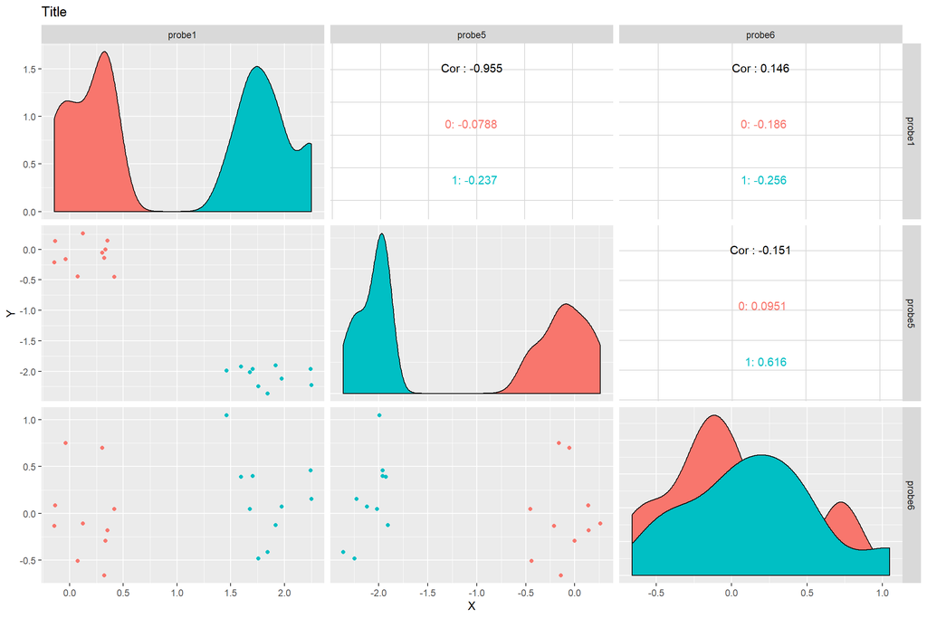

```r
pDat$grp=factor(pDat$grp)


ggpairs(data = pDat,
    mapping = ggplot2::aes_string(color = 'grp'),
        columns = c('probe1', 'probe5', 'probe6'),
        upper = list(continuous = "cor",
                     combo = "box_no_facet",
                     discrete = "facetbar",
                     na = "na"),
        lower = list(continuous = "points",
                     combo = "facethist",
                     discrete = "facetbar",
                     na = "na"),
        diag = list(continuous = "densityDiag",
                    discrete = "barDiag",
                    na = "naDiag"),
        xlab = 'X',
    ylab = 'Y',
    title = 'Title')
```

*GGally* also provides a function *ggcorr* to superimpose correlations onto the heatmap. For instance,

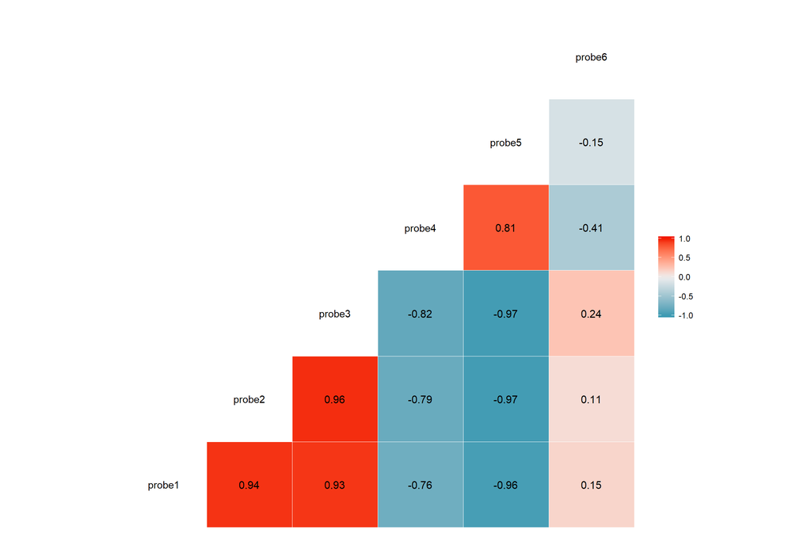

```r
ggcorr(data = pDat[, c(3:8)],
       method = 'pairwise',
       label = TRUE,
       label_round = 2,
       label_size = 4)
```

Our R package *statVisual* is a useful complement to *GGally* since *statVisual* provides many functions (e.g., *BoxROC*, *LinePlot*, *Box*, *ErrBar*) that *GGally* does not provide.

We welcome comments and suggestions to improve *statVisual*.

In future, after appropriate improvements (e.g., replacing the internal datasets with public available datasets or simulated datasets) we will submit *statVisual* to CRAN (https://cran.r-project.org/) and submit a manuscript to a peer-reviewed journal so that other researchers can use this R package to facilitate their data analyses for TM/BM applications.